# Risk Factor Analysis

## Outcome Variable

**Outcome Variable:** haz

## Predictor Variables

**Intervention Variable:** earlybf

**Adjustment Set:**

- arm
- sex
- W_mage
- meducyrs
- feducyrs
- hhwealth_quart
- hfoodsec
- W_mhtcm
- W_mwtkg
- W_mbmi
- vagbrth
- W_gagebrth
- W_birthwt
- W_birthlen
- W_nrooms
- W_nchldlt5
- brthmon
- W_parity
- impfloor
- impsan
- safeh20
- delta_W_mage
- delta_meducyrs
- delta_feducyrs
- delta_hhwealth_quart
- delta_hfoodsec
- delta_W_mhtcm
- delta_W_mwtkg
- delta_W_mbmi
- delta_vagbrth
- delta_W_gagebrth
- delta_W_birthwt
- delta_W_birthlen
- delta_W_nrooms
- delta_W_nchldlt5
- delta_brthmon
- delta_W_parity
- delta_impfloor
- delta_impsan
- delta_safeh20

## Stratifying Variables

The analysis was stratified on these variable(s):

- agecat
- studyid
- country

## Data Summary

| agecat | studyid | country | earlybf | n_cell | n |
| --- | --- | --- | --- | --- | --- |
| Birth | ki0047075b-MAL-ED | BANGLADESH | 1 | 147 | 230 |
| Birth | ki0047075b-MAL-ED | BANGLADESH | 0 | 83 | 230 |
| Birth | ki0047075b-MAL-ED | BRAZIL | 1 | 28 | 65 |
| Birth | ki0047075b-MAL-ED | BRAZIL | 0 | 37 | 65 |
| Birth | ki0047075b-MAL-ED | INDIA | 1 | 32 | 46 |
| Birth | ki0047075b-MAL-ED | INDIA | 0 | 14 | 46 |
| Birth | ki0047075b-MAL-ED | NEPAL | 1 | 14 | 27 |
| Birth | ki0047075b-MAL-ED | NEPAL | 0 | 13 | 27 |
| Birth | ki0047075b-MAL-ED | PERU | 1 | 175 | 233 |
| Birth | ki0047075b-MAL-ED | PERU | 0 | 58 | 233 |
| Birth | ki0047075b-MAL-ED | SOUTH AFRICA | 1 | 69 | 111 |
| Birth | ki0047075b-MAL-ED | SOUTH AFRICA | 0 | 42 | 111 |
| Birth | ki0047075b-MAL-ED | TANZANIA, UNITED REPUBLIC OF | 1 | 111 | 125 |
| Birth | ki0047075b-MAL-ED | TANZANIA, UNITED REPUBLIC OF | 0 | 14 | 125 |
| Birth | ki1000109-EE | PAKISTAN | 1 | 44 | 229 |
| Birth | ki1000109-EE | PAKISTAN | 0 | 185 | 229 |
| Birth | ki1000304b-SAS-CompFeed | INDIA | 1 | 86 | 1207 |
| Birth | ki1000304b-SAS-CompFeed | INDIA | 0 | 1121 | 1207 |
| Birth | ki1017093c-NIH-Crypto | BANGLADESH | 1 | 634 | 732 |
| Birth | ki1017093c-NIH-Crypto | BANGLADESH | 0 | 98 | 732 |
| Birth | ki1113344-GMS-Nepal | NEPAL | 1 | 180 | 632 |
| Birth | ki1113344-GMS-Nepal | NEPAL | 0 | 452 | 632 |
| Birth | ki1126311-ZVITAMBO | ZIMBABWE | 1 | 6556 | 12354 |
| Birth | ki1126311-ZVITAMBO | ZIMBABWE | 0 | 5798 | 12354 |
| Birth | kiGH5241-JiVitA-3 | BANGLADESH | 1 | 236 | 22370 |
| Birth | kiGH5241-JiVitA-3 | BANGLADESH | 0 | 22134 | 22370 |
| Birth | kiGH5241-JiVitA-4 | BANGLADESH | 1 | 1912 | 2823 |
| Birth | kiGH5241-JiVitA-4 | BANGLADESH | 0 | 911 | 2823 |
| 6 months | ki0047075b-MAL-ED | BANGLADESH | 1 | 147 | 240 |
| 6 months | ki0047075b-MAL-ED | BANGLADESH | 0 | 93 | 240 |

[output cut: 52 more lines]

The following strata were considered:

- agecat: 24 months, studyid: ki0047075b-MAL-ED, country: BANGLADESH
- agecat: 24 months, studyid: ki0047075b-MAL-ED, country: BRAZIL
- agecat: 24 months, studyid: ki0047075b-MAL-ED, country: INDIA
- agecat: 24 months, studyid: ki0047075b-MAL-ED, country: NEPAL
- agecat: 24 months, studyid: ki0047075b-MAL-ED, country: PERU
- agecat: 24 months, studyid: ki0047075b-MAL-ED, country: SOUTH AFRICA
- agecat: 24 months, studyid: ki0047075b-MAL-ED, country: TANZANIA, UNITED REPUBLIC OF
- agecat: 24 months, studyid: ki1000109-EE, country: PAKISTAN
- agecat: 24 months, studyid: ki1017093c-NIH-Crypto, country: BANGLADESH
- agecat: 24 months, studyid: ki1113344-GMS-Nepal, country: NEPAL
- agecat: 24 months, studyid: ki1126311-ZVITAMBO, country: ZIMBABWE
- agecat: 24 months, studyid: kiGH5241-JiVitA-3, country: BANGLADESH
- agecat: 24 months, studyid: kiGH5241-JiVitA-4, country: BANGLADESH
- agecat: 6 months, studyid: ki0047075b-MAL-ED, country: BANGLADESH
- agecat: 6 months, studyid: ki0047075b-MAL-ED, country: BRAZIL
- agecat: 6 months, studyid: ki0047075b-MAL-ED, country: INDIA
- agecat: 6 months, studyid: ki0047075b-MAL-ED, country: NEPAL
- agecat: 6 months, studyid: ki0047075b-MAL-ED, country: PERU
- agecat: 6 months, studyid: ki0047075b-MAL-ED, country: SOUTH AFRICA
- agecat: 6 months, studyid: ki0047075b-MAL-ED, country: TANZANIA, UNITED REPUBLIC OF
- agecat: 6 months, studyid: ki1000109-EE, country: PAKISTAN
- agecat: 6 months, studyid: ki1000304b-SAS-CompFeed, country: INDIA
- agecat: 6 months, studyid: ki1017093c-NIH-Crypto, country: BANGLADESH
- agecat: 6 months, studyid: ki1113344-GMS-Nepal, country: NEPAL
- agecat: 6 months, studyid: ki1126311-ZVITAMBO, country: ZIMBABWE
- agecat: 6 months, studyid: kiGH5241-JiVitA-3, country: BANGLADESH
- agecat: 6 months, studyid: kiGH5241-JiVitA-4, country: BANGLADESH
- agecat: Birth, studyid: ki0047075b-MAL-ED, country: BANGLADESH
- agecat: Birth, studyid: ki0047075b-MAL-ED, country: BRAZIL
- agecat: Birth, studyid: ki0047075b-MAL-ED, country: INDIA
- agecat: Birth, studyid: ki0047075b-MAL-ED, country: NEPAL
- agecat: Birth, studyid: ki0047075b-MAL-ED, country: PERU
- agecat: Birth, studyid: ki0047075b-MAL-ED, country: SOUTH AFRICA
- agecat: Birth, studyid: ki0047075b-MAL-ED, country: TANZANIA, UNITED REPUBLIC OF
- agecat: Birth, studyid: ki1000109-EE, country: PAKISTAN
- agecat: Birth, studyid: ki1000304b-SAS-CompFeed, country: INDIA
- agecat: Birth, studyid: ki1017093c-NIH-Crypto, country: BANGLADESH
- agecat: Birth, studyid: ki1113344-GMS-Nepal, country: NEPAL
- agecat: Birth, studyid: ki1126311-ZVITAMBO, country: ZIMBABWE
- agecat: Birth, studyid: kiGH5241-JiVitA-3, country: BANGLADESH
- agecat: Birth, studyid: kiGH5241-JiVitA-4, country: BANGLADESH

### Dropped Strata

Some strata were dropped due to rare outcomes:

- agecat: 24 months, studyid: kiGH5241-JiVitA-3, country: BANGLADESH

## Methods Detail

We’re interested in the causal parameters $E[Y_a]$ for all values of $a \in \mathcal{A}$. These parameters represent the mean outcome if, possibly contrary to fact, we intervened to set all units to have $A=a$. Under the randomization and positivity assumptions, these are identified by the statistical parameters $\psi_a=E_W[E_{Y|A,W}(Y|A=a,W)]$. In addition, we’re interested in the mean of $Y$, $E[Y]$ under no intervention (the observed mean). We will estimate these parameters by using SuperLearner to fit the relevant likelihood factors – $E_{Y|A,W}(Y|A=a,W)$ and $p(A=a|W)$, and then updating our likelihood fit using a joint TMLE.

For unadjusted analyses ($W=\{\}$), initial likelihoods were estimated using Lrnr_glm to estimate the simple $E(Y|A)$ and Lrnr_mean to estimate $p(A)$. For adjusted analyses, a small library containing Lrnr_glmnet, Lrnr_xgboost, and Lrnr_mean was used.

Having estimated these parameters, we will then use the delta method to estimate relative risks and attributable risks relative to a prespecified baseline level of $A$.

# Results Detail

## Results Plots

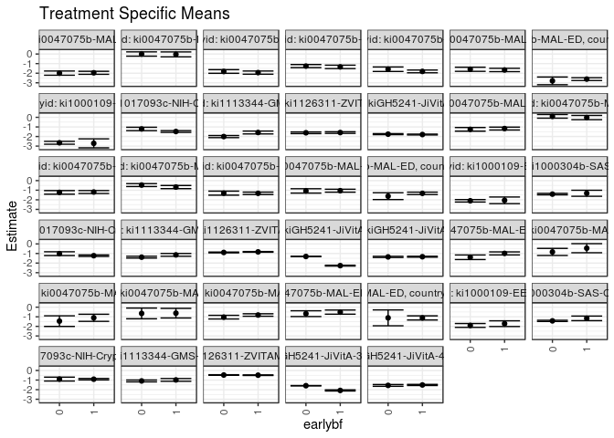

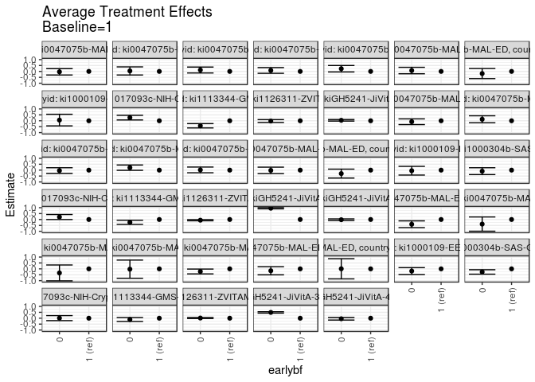

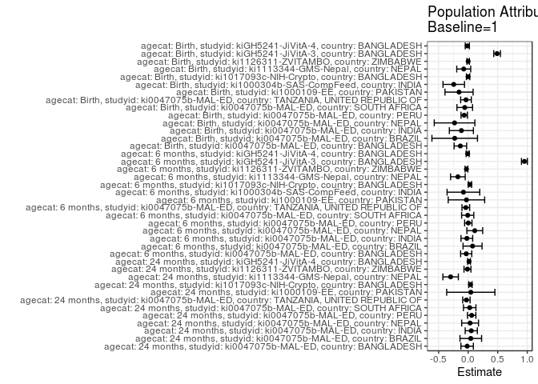

## Results Table

### Parameter: TSM

| agecat | studyid | country | intervention_level | baseline_level | estimate | ci_lower | ci_upper |
| --- | --- | --- | --- | --- | --- | --- | --- |
| Birth | ki0047075b-MAL-ED | BANGLADESH | 1 | NA | -0.9896354 | -1.1488014 | -0.8304693 |
| Birth | ki0047075b-MAL-ED | BANGLADESH | 0 | NA | -1.3931673 | -1.6309578 | -1.1553768 |
| Birth | ki0047075b-MAL-ED | BRAZIL | 1 | NA | -0.4483051 | -0.9208940 | 0.0242837 |
| Birth | ki0047075b-MAL-ED | BRAZIL | 0 | NA | -0.8381606 | -1.2080546 | -0.4682667 |
| Birth | ki0047075b-MAL-ED | INDIA | 1 | NA | -1.1074518 | -1.4766166 | -0.7382870 |
| Birth | ki0047075b-MAL-ED | INDIA | 0 | NA | -1.4522318 | -2.0068230 | -0.8976406 |
| Birth | ki0047075b-MAL-ED | NEPAL | 1 | NA | -0.6231553 | -1.1241038 | -0.1222068 |
| Birth | ki0047075b-MAL-ED | NEPAL | 0 | NA | -0.6491029 | -1.2076741 | -0.0905317 |
| Birth | ki0047075b-MAL-ED | PERU | 1 | NA | -0.8157199 | -0.9439306 | -0.6875093 |
| Birth | ki0047075b-MAL-ED | PERU | 0 | NA | -1.0384091 | -1.2287001 | -0.8481181 |
| Birth | ki0047075b-MAL-ED | SOUTH AFRICA | 1 | NA | -0.5132465 | -0.7285369 | -0.2979562 |
| Birth | ki0047075b-MAL-ED | SOUTH AFRICA | 0 | NA | -0.6747952 | -0.9748494 | -0.3747410 |
| Birth | ki0047075b-MAL-ED | TANZANIA, UNITED REPUBLIC OF | 1 | NA | -1.1188676 | -1.3348431 | -0.9028920 |
| Birth | ki0047075b-MAL-ED | TANZANIA, UNITED REPUBLIC OF | 0 | NA | -1.1116583 | -1.9384268 | -0.2848898 |
| Birth | ki1000109-EE | PAKISTAN | 1 | NA | -1.7168966 | -2.0148828 | -1.4189104 |
| Birth | ki1000109-EE | PAKISTAN | 0 | NA | -1.9031337 | -2.1049722 | -1.7012953 |
| Birth | ki1000304b-SAS-CompFeed | INDIA | 1 | NA | -1.1634303 | -1.4025917 | -0.9242689 |
| Birth | ki1000304b-SAS-CompFeed | INDIA | 0 | NA | -1.4262554 | -1.4888925 | -1.3636182 |
| Birth | ki1017093c-NIH-Crypto | BANGLADESH | 1 | NA | -0.9083866 | -0.9835452 | -0.8332280 |
| Birth | ki1017093c-NIH-Crypto | BANGLADESH | 0 | NA | -0.8988413 | -1.1015476 | -0.6961351 |
| Birth | ki1113344-GMS-Nepal | NEPAL | 1 | NA | -0.9829915 | -1.1247262 | -0.8412567 |
| Birth | ki1113344-GMS-Nepal | NEPAL | 0 | NA | -1.0899638 | -1.1871865 | -0.9927411 |
| Birth | ki1126311-ZVITAMBO | ZIMBABWE | 1 | NA | -0.4896234 | -0.5193931 | -0.4598537 |
| Birth | ki1126311-ZVITAMBO | ZIMBABWE | 0 | NA | -0.4742933 | -0.5056538 | -0.4429328 |
| Birth | kiGH5241-JiVitA-3 | BANGLADESH | 1 | NA | -2.0795464 | -2.1360972 | -2.0229955 |
| Birth | kiGH5241-JiVitA-3 | BANGLADESH | 0 | NA | -1.5871599 | -1.6066926 | -1.5676272 |
| Birth | kiGH5241-JiVitA-4 | BANGLADESH | 1 | NA | -1.5090946 | -1.5665483 | -1.4516409 |
| Birth | kiGH5241-JiVitA-4 | BANGLADESH | 0 | NA | -1.5555475 | -1.6482054 | -1.4628895 |
| 6 months | ki0047075b-MAL-ED | BANGLADESH | 1 | NA | -1.1725322 | -1.3216517 | -1.0234127 |
| 6 months | ki0047075b-MAL-ED | BANGLADESH | 0 | NA | -1.2526042 | -1.4424997 | -1.0627088 |
| 6 months | ki0047075b-MAL-ED | BRAZIL | 1 | NA | -0.0265788 | -0.2480129 | 0.1948553 |
| 6 months | ki0047075b-MAL-ED | BRAZIL | 0 | NA | 0.1012172 | -0.0895970 | 0.2920314 |
| 6 months | ki0047075b-MAL-ED | INDIA | 1 | NA | -1.1891480 | -1.3426072 | -1.0356889 |
| 6 months | ki0047075b-MAL-ED | INDIA | 0 | NA | -1.2273609 | -1.4143316 | -1.0403903 |
| 6 months | ki0047075b-MAL-ED | NEPAL | 1 | NA | -0.6735031 | -0.8384302 | -0.5085760 |
| 6 months | ki0047075b-MAL-ED | NEPAL | 0 | NA | -0.4641724 | -0.6157425 | -0.3126022 |
| 6 months | ki0047075b-MAL-ED | PERU | 1 | NA | -1.3260751 | -1.4528261 | -1.1993242 |
| 6 months | ki0047075b-MAL-ED | PERU | 0 | NA | -1.3075716 | -1.5167729 | -1.0983702 |
| 6 months | ki0047075b-MAL-ED | SOUTH AFRICA | 1 | NA | -1.0524384 | -1.2065046 | -0.8983722 |
| 6 months | ki0047075b-MAL-ED | SOUTH AFRICA | 0 | NA | -1.0733413 | -1.3010351 | -0.8456475 |
| 6 months | ki0047075b-MAL-ED | TANZANIA, UNITED REPUBLIC OF | 1 | NA | -1.3289232 | -1.4564808 | -1.2013657 |
| 6 months | ki0047075b-MAL-ED | TANZANIA, UNITED REPUBLIC OF | 0 | NA | -1.6217381 | -1.9772218 | -1.2662544 |
| 6 months | ki1000109-EE | PAKISTAN | 1 | NA | -2.0547840 | -2.4018716 | -1.7076964 |
| 6 months | ki1000109-EE | PAKISTAN | 0 | NA | -2.1036925 | -2.2324784 | -1.9749065 |
| 6 months | ki1000304b-SAS-CompFeed | INDIA | 1 | NA | -1.3216273 | -1.6354080 | -1.0078465 |
| 6 months | ki1000304b-SAS-CompFeed | INDIA | 0 | NA | -1.4088177 | -1.4845774 | -1.3330581 |
| 6 months | ki1017093c-NIH-Crypto | BANGLADESH | 1 | NA | -1.2286362 | -1.3051430 | -1.1521294 |
| 6 months | ki1017093c-NIH-Crypto | BANGLADESH | 0 | NA | -1.0182542 | -1.2153686 | -0.8211397 |
| 6 months | ki1113344-GMS-Nepal | NEPAL | 1 | NA | -1.1439043 | -1.2908175 | -0.9969910 |
| 6 months | ki1113344-GMS-Nepal | NEPAL | 0 | NA | -1.3835455 | -1.4803237 | -1.2867673 |
| 6 months | ki1126311-ZVITAMBO | ZIMBABWE | 1 | NA | -0.8335228 | -0.8690347 | -0.7980110 |
| 6 months | ki1126311-ZVITAMBO | ZIMBABWE | 0 | NA | -0.8928069 | -0.9312013 | -0.8544126 |
| 6 months | kiGH5241-JiVitA-3 | BANGLADESH | 1 | NA | -2.2655306 | -2.3116541 | -2.2194070 |
| 6 months | kiGH5241-JiVitA-3 | BANGLADESH | 0 | NA | -1.3111354 | -1.3347446 | -1.2875262 |
| 6 months | kiGH5241-JiVitA-4 | BANGLADESH | 1 | NA | -1.3368270 | -1.3826845 | -1.2909695 |
| 6 months | kiGH5241-JiVitA-4 | BANGLADESH | 0 | NA | -1.3557768 | -1.4146523 | -1.2969013 |
| 24 months | ki0047075b-MAL-ED | BANGLADESH | 1 | NA | -1.9564218 | -2.1126978 | -1.8001458 |
| 24 months | ki0047075b-MAL-ED | BANGLADESH | 0 | NA | -1.9908388 | -2.2078986 | -1.7737790 |
| 24 months | ki0047075b-MAL-ED | BRAZIL | 1 | NA | -0.0380199 | -0.2958027 | 0.2197629 |
| 24 months | ki0047075b-MAL-ED | BRAZIL | 0 | NA | 0.0028280 | -0.2211489 | 0.2268049 |
| 24 months | ki0047075b-MAL-ED | INDIA | 1 | NA | -1.9387913 | -2.1037497 | -1.7738329 |
| 24 months | ki0047075b-MAL-ED | INDIA | 0 | NA | -1.8205359 | -2.0106396 | -1.6304321 |
| 24 months | ki0047075b-MAL-ED | NEPAL | 1 | NA | -1.3403628 | -1.5177835 | -1.1629420 |
| 24 months | ki0047075b-MAL-ED | NEPAL | 0 | NA | -1.2581684 | -1.4206120 | -1.0957248 |
| 24 months | ki0047075b-MAL-ED | PERU | 1 | NA | -1.8117712 | -1.9542143 | -1.6693280 |
| 24 months | ki0047075b-MAL-ED | PERU | 0 | NA | -1.5840013 | -1.8169748 | -1.3510279 |
| 24 months | ki0047075b-MAL-ED | SOUTH AFRICA | 1 | NA | -1.6624502 | -1.8365114 | -1.4883889 |
| 24 months | ki0047075b-MAL-ED | SOUTH AFRICA | 0 | NA | -1.5882091 | -1.8014802 | -1.3749380 |
| 24 months | ki0047075b-MAL-ED | TANZANIA, UNITED REPUBLIC OF | 1 | NA | -2.6155855 | -2.7610496 | -2.4701214 |
| 24 months | ki0047075b-MAL-ED | TANZANIA, UNITED REPUBLIC OF | 0 | NA | -2.7973112 | -3.1987836 | -2.3958388 |
| 24 months | ki1000109-EE | PAKISTAN | 1 | NA | -2.7123933 | -3.1800789 | -2.2447077 |
| 24 months | ki1000109-EE | PAKISTAN | 0 | NA | -2.6547080 | -2.8035060 | -2.5059100 |
| 24 months | ki1017093c-NIH-Crypto | BANGLADESH | 1 | NA | -1.4794152 | -1.5713535 | -1.3874769 |
| 24 months | ki1017093c-NIH-Crypto | BANGLADESH | 0 | NA | -1.2124804 | -1.3884374 | -1.0365234 |
| 24 months | ki1113344-GMS-Nepal | NEPAL | 1 | NA | -1.5826596 | -1.7311521 | -1.4341670 |
| 24 months | ki1113344-GMS-Nepal | NEPAL | 0 | NA | -2.0072835 | -2.1169284 | -1.8976385 |
| 24 months | ki1126311-ZVITAMBO | ZIMBABWE | 1 | NA | -1.5888261 | -1.6747270 | -1.5029252 |
| 24 months | ki1126311-ZVITAMBO | ZIMBABWE | 0 | NA | -1.6110369 | -1.6961907 | -1.5258831 |
| 24 months | kiGH5241-JiVitA-4 | BANGLADESH | 1 | NA | -1.7958735 | -1.8400617 | -1.7516853 |
| 24 months | kiGH5241-JiVitA-4 | BANGLADESH | 0 | NA | -1.7559331 | -1.8091476 | -1.7027187 |

### Parameter: E(Y)

| agecat | studyid | country | intervention_level | baseline_level | estimate | ci_lower | ci_upper |
| --- | --- | --- | --- | --- | --- | --- | --- |
| Birth | ki0047075b-MAL-ED | BANGLADESH | NA | NA | -1.1218261 | -1.2566576 | -0.9869945 |
| Birth | ki0047075b-MAL-ED | BRAZIL | NA | NA | -0.6760000 | -0.9521457 | -0.3998543 |
| Birth | ki0047075b-MAL-ED | INDIA | NA | NA | -1.2221739 | -1.5203945 | -0.9239534 |
| Birth | ki0047075b-MAL-ED | NEPAL | NA | NA | -0.8533333 | -1.2104864 | -0.4961803 |
| Birth | ki0047075b-MAL-ED | PERU | NA | NA | -0.8827897 | -1.0001058 | -0.7654736 |
| Birth | ki0047075b-MAL-ED | SOUTH AFRICA | NA | NA | -0.5709009 | -0.7569265 | -0.3848753 |
| Birth | ki0047075b-MAL-ED | TANZANIA, UNITED REPUBLIC OF | NA | NA | -1.1556000 | -1.3655361 | -0.9456639 |
| Birth | ki1000109-EE | PAKISTAN | NA | NA | -1.8713537 | -2.0647180 | -1.6779894 |
| Birth | ki1000304b-SAS-CompFeed | INDIA | NA | NA | -1.4072245 | -1.4817853 | -1.3326638 |
| Birth | ki1017093c-NIH-Crypto | BANGLADESH | NA | NA | -0.9094945 | -0.9809370 | -0.8380521 |
| Birth | ki1113344-GMS-Nepal | NEPAL | NA | NA | -1.0578481 | -1.1411010 | -0.9745953 |
| Birth | ki1126311-ZVITAMBO | ZIMBABWE | NA | NA | -0.4895257 | -0.5113672 | -0.4676841 |
| Birth | kiGH5241-JiVitA-3 | BANGLADESH | NA | NA | -1.5896710 | -1.6089649 | -1.5703770 |
| Birth | kiGH5241-JiVitA-4 | BANGLADESH | NA | NA | -1.5232908 | -1.5723277 | -1.4742539 |
| 6 months | ki0047075b-MAL-ED | BANGLADESH | NA | NA | -1.2056389 | -1.3233420 | -1.0879358 |
| 6 months | ki0047075b-MAL-ED | BRAZIL | NA | NA | 0.0475758 | -0.0963508 | 0.1915023 |
| 6 months | ki0047075b-MAL-ED | INDIA | NA | NA | -1.2115254 | -1.3298727 | -1.0931782 |
| 6 months | ki0047075b-MAL-ED | NEPAL | NA | NA | -0.5615819 | -0.6741832 | -0.4489807 |
| 6 months | ki0047075b-MAL-ED | PERU | NA | NA | -1.3236661 | -1.4316775 | -1.2156546 |
| 6 months | ki0047075b-MAL-ED | SOUTH AFRICA | NA | NA | -1.0598800 | -1.1885688 | -0.9311912 |
| 6 months | ki0047075b-MAL-ED | TANZANIA, UNITED REPUBLIC OF | NA | NA | -1.3687449 | -1.4907629 | -1.2467270 |
| 6 months | ki1000109-EE | PAKISTAN | NA | NA | -2.0838858 | -2.2054394 | -1.9623322 |
| 6 months | ki1000304b-SAS-CompFeed | INDIA | NA | NA | -1.4018563 | -1.4810585 | -1.3226541 |
| 6 months | ki1017093c-NIH-Crypto | BANGLADESH | NA | NA | -1.1986783 | -1.2700937 | -1.1272630 |
| 6 months | ki1113344-GMS-Nepal | NEPAL | NA | NA | -1.3175310 | -1.3993963 | -1.2356656 |
| 6 months | ki1126311-ZVITAMBO | ZIMBABWE | NA | NA | -0.8625370 | -0.8897591 | -0.8353150 |
| 6 months | kiGH5241-JiVitA-3 | BANGLADESH | NA | NA | -1.3130932 | -1.3362359 | -1.2899505 |
| 6 months | kiGH5241-JiVitA-4 | BANGLADESH | NA | NA | -1.3447940 | -1.3820261 | -1.3075620 |
| 24 months | ki0047075b-MAL-ED | BANGLADESH | NA | NA | -1.9735782 | -2.1004502 | -1.8467062 |
| 24 months | ki0047075b-MAL-ED | BRAZIL | NA | NA | 0.0061144 | -0.1625850 | 0.1748138 |
| 24 months | ki0047075b-MAL-ED | INDIA | NA | NA | -1.8861894 | -2.0110006 | -1.7613783 |
| 24 months | ki0047075b-MAL-ED | NEPAL | NA | NA | -1.3075877 | -1.4270718 | -1.1881037 |
| 24 months | ki0047075b-MAL-ED | PERU | NA | NA | -1.7524710 | -1.8736426 | -1.6312994 |
| 24 months | ki0047075b-MAL-ED | SOUTH AFRICA | NA | NA | -1.6365071 | -1.7722110 | -1.5008032 |
| 24 months | ki0047075b-MAL-ED | TANZANIA, UNITED REPUBLIC OF | NA | NA | -2.6455607 | -2.7807256 | -2.5103959 |
| 24 months | ki1000109-EE | PAKISTAN | NA | NA | -2.6678252 | -2.8138884 | -2.5217620 |
| 24 months | ki1017093c-NIH-Crypto | BANGLADESH | NA | NA | -1.4412646 | -1.5249156 | -1.3576135 |
| 24 months | ki1113344-GMS-Nepal | NEPAL | NA | NA | -1.8793783 | -1.9705101 | -1.7882464 |
| 24 months | ki1126311-ZVITAMBO | ZIMBABWE | NA | NA | -1.6006366 | -1.6621572 | -1.5391159 |
| 24 months | kiGH5241-JiVitA-4 | BANGLADESH | NA | NA | -1.7807218 | -1.8162478 | -1.7451958 |

### Parameter: ATE

| agecat | studyid | country | intervention_level | baseline_level | estimate | ci_lower | ci_upper |
| --- | --- | --- | --- | --- | --- | --- | --- |
| Birth | ki0047075b-MAL-ED | BANGLADESH | 1 | 1 | 0.0000000 | 0.0000000 | 0.0000000 |
| Birth | ki0047075b-MAL-ED | BANGLADESH | 0 | 1 | -0.4035319 | -0.6904543 | -0.1166095 |
| Birth | ki0047075b-MAL-ED | BRAZIL | 1 | 1 | 0.0000000 | 0.0000000 | 0.0000000 |
| Birth | ki0047075b-MAL-ED | BRAZIL | 0 | 1 | -0.3898555 | -0.9925512 | 0.2128402 |
| Birth | ki0047075b-MAL-ED | INDIA | 1 | 1 | 0.0000000 | 0.0000000 | 0.0000000 |
| Birth | ki0047075b-MAL-ED | INDIA | 0 | 1 | -0.3447800 | -1.0184288 | 0.3288688 |
| Birth | ki0047075b-MAL-ED | NEPAL | 1 | 1 | 0.0000000 | 0.0000000 | 0.0000000 |
| Birth | ki0047075b-MAL-ED | NEPAL | 0 | 1 | -0.0259476 | -0.7960119 | 0.7441167 |
| Birth | ki0047075b-MAL-ED | PERU | 1 | 1 | 0.0000000 | 0.0000000 | 0.0000000 |
| Birth | ki0047075b-MAL-ED | PERU | 0 | 1 | -0.2226892 | -0.4282633 | -0.0171150 |
| Birth | ki0047075b-MAL-ED | SOUTH AFRICA | 1 | 1 | 0.0000000 | 0.0000000 | 0.0000000 |
| Birth | ki0047075b-MAL-ED | SOUTH AFRICA | 0 | 1 | -0.1615487 | -0.5064473 | 0.1833500 |
| Birth | ki0047075b-MAL-ED | TANZANIA, UNITED REPUBLIC OF | 1 | 1 | 0.0000000 | 0.0000000 | 0.0000000 |
| Birth | ki0047075b-MAL-ED | TANZANIA, UNITED REPUBLIC OF | 0 | 1 | 0.0072093 | -0.8483417 | 0.8627604 |
| Birth | ki1000109-EE | PAKISTAN | 1 | 1 | 0.0000000 | 0.0000000 | 0.0000000 |
| Birth | ki1000109-EE | PAKISTAN | 0 | 1 | -0.1862372 | -0.4754895 | 0.1030152 |
| Birth | ki1000304b-SAS-CompFeed | INDIA | 1 | 1 | 0.0000000 | 0.0000000 | 0.0000000 |
| Birth | ki1000304b-SAS-CompFeed | INDIA | 0 | 1 | -0.2628250 | -0.4506469 | -0.0750032 |
| Birth | ki1017093c-NIH-Crypto | BANGLADESH | 1 | 1 | 0.0000000 | 0.0000000 | 0.0000000 |
| Birth | ki1017093c-NIH-Crypto | BANGLADESH | 0 | 1 | 0.0095453 | -0.2037536 | 0.2228442 |
| Birth | ki1113344-GMS-Nepal | NEPAL | 1 | 1 | 0.0000000 | 0.0000000 | 0.0000000 |
| Birth | ki1113344-GMS-Nepal | NEPAL | 0 | 1 | -0.1069723 | -0.2728058 | 0.0588612 |
| Birth | ki1126311-ZVITAMBO | ZIMBABWE | 1 | 1 | 0.0000000 | 0.0000000 | 0.0000000 |
| Birth | ki1126311-ZVITAMBO | ZIMBABWE | 0 | 1 | 0.0153301 | -0.0265350 | 0.0571951 |
| Birth | kiGH5241-JiVitA-3 | BANGLADESH | 1 | 1 | 0.0000000 | 0.0000000 | 0.0000000 |
| Birth | kiGH5241-JiVitA-3 | BANGLADESH | 0 | 1 | 0.4923865 | 0.4345525 | 0.5502205 |
| Birth | kiGH5241-JiVitA-4 | BANGLADESH | 1 | 1 | 0.0000000 | 0.0000000 | 0.0000000 |
| Birth | kiGH5241-JiVitA-4 | BANGLADESH | 0 | 1 | -0.0464529 | -0.1555057 | 0.0625999 |
| 6 months | ki0047075b-MAL-ED | BANGLADESH | 1 | 1 | 0.0000000 | 0.0000000 | 0.0000000 |
| 6 months | ki0047075b-MAL-ED | BANGLADESH | 0 | 1 | -0.0800720 | -0.3220440 | 0.1619000 |
| 6 months | ki0047075b-MAL-ED | BRAZIL | 1 | 1 | 0.0000000 | 0.0000000 | 0.0000000 |
| 6 months | ki0047075b-MAL-ED | BRAZIL | 0 | 1 | 0.1277960 | -0.1656418 | 0.4212338 |
| 6 months | ki0047075b-MAL-ED | INDIA | 1 | 1 | 0.0000000 | 0.0000000 | 0.0000000 |
| 6 months | ki0047075b-MAL-ED | INDIA | 0 | 1 | -0.0382129 | -0.2804940 | 0.2040682 |
| 6 months | ki0047075b-MAL-ED | NEPAL | 1 | 1 | 0.0000000 | 0.0000000 | 0.0000000 |
| 6 months | ki0047075b-MAL-ED | NEPAL | 0 | 1 | 0.2093307 | -0.0154869 | 0.4341484 |
| 6 months | ki0047075b-MAL-ED | PERU | 1 | 1 | 0.0000000 | 0.0000000 | 0.0000000 |
| 6 months | ki0047075b-MAL-ED | PERU | 0 | 1 | 0.0185036 | -0.2253604 | 0.2623675 |
| 6 months | ki0047075b-MAL-ED | SOUTH AFRICA | 1 | 1 | 0.0000000 | 0.0000000 | 0.0000000 |
| 6 months | ki0047075b-MAL-ED | SOUTH AFRICA | 0 | 1 | -0.0209028 | -0.2948000 | 0.2529943 |
| 6 months | ki0047075b-MAL-ED | TANZANIA, UNITED REPUBLIC OF | 1 | 1 | 0.0000000 | 0.0000000 | 0.0000000 |
| 6 months | ki0047075b-MAL-ED | TANZANIA, UNITED REPUBLIC OF | 0 | 1 | -0.2928149 | -0.6715804 | 0.0859507 |
| 6 months | ki1000109-EE | PAKISTAN | 1 | 1 | 0.0000000 | 0.0000000 | 0.0000000 |
| 6 months | ki1000109-EE | PAKISTAN | 0 | 1 | -0.0489085 | -0.4178226 | 0.3200057 |
| 6 months | ki1000304b-SAS-CompFeed | INDIA | 1 | 1 | 0.0000000 | 0.0000000 | 0.0000000 |
| 6 months | ki1000304b-SAS-CompFeed | INDIA | 0 | 1 | -0.0871905 | -0.3777007 | 0.2033198 |
| 6 months | ki1017093c-NIH-Crypto | BANGLADESH | 1 | 1 | 0.0000000 | 0.0000000 | 0.0000000 |
| 6 months | ki1017093c-NIH-Crypto | BANGLADESH | 0 | 1 | 0.2103820 | -0.0012752 | 0.4220393 |
| 6 months | ki1113344-GMS-Nepal | NEPAL | 1 | 1 | 0.0000000 | 0.0000000 | 0.0000000 |
| 6 months | ki1113344-GMS-Nepal | NEPAL | 0 | 1 | -0.2396413 | -0.4144674 | -0.0648151 |
| 6 months | ki1126311-ZVITAMBO | ZIMBABWE | 1 | 1 | 0.0000000 | 0.0000000 | 0.0000000 |
| 6 months | ki1126311-ZVITAMBO | ZIMBABWE | 0 | 1 | -0.0592841 | -0.1086958 | -0.0098724 |
| 6 months | kiGH5241-JiVitA-3 | BANGLADESH | 1 | 1 | 0.0000000 | 0.0000000 | 0.0000000 |
| 6 months | kiGH5241-JiVitA-3 | BANGLADESH | 0 | 1 | 0.9543951 | 0.9032648 | 1.0055255 |
| 6 months | kiGH5241-JiVitA-4 | BANGLADESH | 1 | 1 | 0.0000000 | 0.0000000 | 0.0000000 |
| 6 months | kiGH5241-JiVitA-4 | BANGLADESH | 0 | 1 | -0.0189498 | -0.0911737 | 0.0532740 |
| 24 months | ki0047075b-MAL-ED | BANGLADESH | 1 | 1 | 0.0000000 | 0.0000000 | 0.0000000 |
| 24 months | ki0047075b-MAL-ED | BANGLADESH | 0 | 1 | -0.0344170 | -0.3025277 | 0.2336938 |
| 24 months | ki0047075b-MAL-ED | BRAZIL | 1 | 1 | 0.0000000 | 0.0000000 | 0.0000000 |
| 24 months | ki0047075b-MAL-ED | BRAZIL | 0 | 1 | 0.0408479 | -0.3022247 | 0.3839206 |
| 24 months | ki0047075b-MAL-ED | INDIA | 1 | 1 | 0.0000000 | 0.0000000 | 0.0000000 |
| 24 months | ki0047075b-MAL-ED | INDIA | 0 | 1 | 0.1182554 | -0.1316708 | 0.3681817 |
| 24 months | ki0047075b-MAL-ED | NEPAL | 1 | 1 | 0.0000000 | 0.0000000 | 0.0000000 |
| 24 months | ki0047075b-MAL-ED | NEPAL | 0 | 1 | 0.0821944 | -0.1587251 | 0.3231139 |
| 24 months | ki0047075b-MAL-ED | PERU | 1 | 1 | 0.0000000 | 0.0000000 | 0.0000000 |
| 24 months | ki0047075b-MAL-ED | PERU | 0 | 1 | 0.2277699 | -0.0456048 | 0.5011445 |
| 24 months | ki0047075b-MAL-ED | SOUTH AFRICA | 1 | 1 | 0.0000000 | 0.0000000 | 0.0000000 |
| 24 months | ki0047075b-MAL-ED | SOUTH AFRICA | 0 | 1 | 0.0742410 | -0.1986995 | 0.3471816 |
| 24 months | ki0047075b-MAL-ED | TANZANIA, UNITED REPUBLIC OF | 1 | 1 | 0.0000000 | 0.0000000 | 0.0000000 |
| 24 months | ki0047075b-MAL-ED | TANZANIA, UNITED REPUBLIC OF | 0 | 1 | -0.1817257 | -0.6077702 | 0.2443188 |
| 24 months | ki1000109-EE | PAKISTAN | 1 | 1 | 0.0000000 | 0.0000000 | 0.0000000 |
| 24 months | ki1000109-EE | PAKISTAN | 0 | 1 | 0.0576853 | -0.4338050 | 0.5491757 |
| 24 months | ki1017093c-NIH-Crypto | BANGLADESH | 1 | 1 | 0.0000000 | 0.0000000 | 0.0000000 |
| 24 months | ki1017093c-NIH-Crypto | BANGLADESH | 0 | 1 | 0.2669349 | 0.0695323 | 0.4643374 |
| 24 months | ki1113344-GMS-Nepal | NEPAL | 1 | 1 | 0.0000000 | 0.0000000 | 0.0000000 |
| 24 months | ki1113344-GMS-Nepal | NEPAL | 0 | 1 | -0.4246239 | -0.6080610 | -0.2411868 |
| 24 months | ki1126311-ZVITAMBO | ZIMBABWE | 1 | 1 | 0.0000000 | 0.0000000 | 0.0000000 |
| 24 months | ki1126311-ZVITAMBO | ZIMBABWE | 0 | 1 | -0.0222108 | -0.1413090 | 0.0968874 |
| 24 months | kiGH5241-JiVitA-4 | BANGLADESH | 1 | 1 | 0.0000000 | 0.0000000 | 0.0000000 |
| 24 months | kiGH5241-JiVitA-4 | BANGLADESH | 0 | 1 | 0.0399404 | -0.0255653 | 0.1054460 |

### Parameter: PAR

| agecat | studyid | country | intervention_level | baseline_level | estimate | ci_lower | ci_upper |
| --- | --- | --- | --- | --- | --- | --- | --- |
| Birth | ki0047075b-MAL-ED | BANGLADESH | 1 | NA | -0.1321907 | -0.2382063 | -0.0261751 |
| Birth | ki0047075b-MAL-ED | BRAZIL | 1 | NA | -0.2276949 | -0.6133958 | 0.1580061 |
| Birth | ki0047075b-MAL-ED | INDIA | 1 | NA | -0.1147222 | -0.3184415 | 0.0889972 |
| Birth | ki0047075b-MAL-ED | NEPAL | 1 | NA | -0.2301781 | -0.5740600 | 0.1137039 |
| Birth | ki0047075b-MAL-ED | PERU | 1 | NA | -0.0670698 | -0.1208320 | -0.0133076 |
| Birth | ki0047075b-MAL-ED | SOUTH AFRICA | 1 | NA | -0.0576544 | -0.1897693 | 0.0744605 |
| Birth | ki0047075b-MAL-ED | TANZANIA, UNITED REPUBLIC OF | 1 | NA | -0.0367324 | -0.1269771 | 0.0535123 |
| Birth | ki1000109-EE | PAKISTAN | 1 | NA | -0.1544571 | -0.3923147 | 0.0834004 |
| Birth | ki1000304b-SAS-CompFeed | INDIA | 1 | NA | -0.2437942 | -0.4258416 | -0.0617468 |
| Birth | ki1017093c-NIH-Crypto | BANGLADESH | 1 | NA | -0.0011079 | -0.0294650 | 0.0272491 |
| Birth | ki1113344-GMS-Nepal | NEPAL | 1 | NA | -0.0748566 | -0.1930352 | 0.0433219 |
| Birth | ki1126311-ZVITAMBO | ZIMBABWE | 1 | NA | 0.0000977 | -0.0211618 | 0.0213572 |
| Birth | kiGH5241-JiVitA-3 | BANGLADESH | 1 | NA | 0.4898754 | 0.4337068 | 0.5460440 |
| Birth | kiGH5241-JiVitA-4 | BANGLADESH | 1 | NA | -0.0141962 | -0.0493603 | 0.0209678 |
| 6 months | ki0047075b-MAL-ED | BANGLADESH | 1 | NA | -0.0331067 | -0.1276893 | 0.0614760 |
| 6 months | ki0047075b-MAL-ED | BRAZIL | 1 | NA | 0.0741545 | -0.0865891 | 0.2348982 |
| 6 months | ki0047075b-MAL-ED | INDIA | 1 | NA | -0.0223774 | -0.1214178 | 0.0766630 |
| 6 months | ki0047075b-MAL-ED | NEPAL | 1 | NA | 0.1119212 | -0.0220974 | 0.2459398 |
| 6 months | ki0047075b-MAL-ED | PERU | 1 | NA | 0.0024091 | -0.0597358 | 0.0645539 |
| 6 months | ki0047075b-MAL-ED | SOUTH AFRICA | 1 | NA | -0.0074416 | -0.1103968 | 0.0955136 |
| 6 months | ki0047075b-MAL-ED | TANZANIA, UNITED REPUBLIC OF | 1 | NA | -0.0398217 | -0.1048560 | 0.0252126 |
| 6 months | ki1000109-EE | PAKISTAN | 1 | NA | -0.0291018 | -0.3377552 | 0.2795516 |
| 6 months | ki1000304b-SAS-CompFeed | INDIA | 1 | NA | -0.0802290 | -0.3566709 | 0.1962129 |
| 6 months | ki1017093c-NIH-Crypto | BANGLADESH | 1 | NA | 0.0299579 | 0.0011761 | 0.0587397 |
| 6 months | ki1113344-GMS-Nepal | NEPAL | 1 | NA | -0.1736267 | -0.2973100 | -0.0499434 |
| 6 months | ki1126311-ZVITAMBO | ZIMBABWE | 1 | NA | -0.0290142 | -0.0521124 | -0.0059160 |
| 6 months | kiGH5241-JiVitA-3 | BANGLADESH | 1 | NA | 0.9524373 | 0.9025067 | 1.0023680 |
| 6 months | kiGH5241-JiVitA-4 | BANGLADESH | 1 | NA | -0.0079670 | -0.0340728 | 0.0181387 |
| 24 months | ki0047075b-MAL-ED | BANGLADESH | 1 | NA | -0.0171564 | -0.1224315 | 0.0881187 |
| 24 months | ki0047075b-MAL-ED | BRAZIL | 1 | NA | 0.0441343 | -0.1387050 | 0.2269736 |
| 24 months | ki0047075b-MAL-ED | INDIA | 1 | NA | 0.0526019 | -0.0501331 | 0.1553369 |
| 24 months | ki0047075b-MAL-ED | NEPAL | 1 | NA | 0.0327751 | -0.1096393 | 0.1751894 |
| 24 months | ki0047075b-MAL-ED | PERU | 1 | NA | 0.0593002 | -0.0117684 | 0.1303688 |
| 24 months | ki0047075b-MAL-ED | SOUTH AFRICA | 1 | NA | 0.0259431 | -0.0798087 | 0.1316948 |
| 24 months | ki0047075b-MAL-ED | TANZANIA, UNITED REPUBLIC OF | 1 | NA | -0.0299753 | -0.0922637 | 0.0323132 |
| 24 months | ki1000109-EE | PAKISTAN | 1 | NA | 0.0445681 | -0.3633964 | 0.4525327 |
| 24 months | ki1017093c-NIH-Crypto | BANGLADESH | 1 | NA | 0.0381506 | 0.0098092 | 0.0664921 |
| 24 months | ki1113344-GMS-Nepal | NEPAL | 1 | NA | -0.2967187 | -0.4275821 | -0.1658554 |
| 24 months | ki1126311-ZVITAMBO | ZIMBABWE | 1 | NA | -0.0118104 | -0.0703887 | 0.0467678 |
| 24 months | kiGH5241-JiVitA-4 | BANGLADESH | 1 | NA | 0.0151517 | -0.0084024 | 0.0387058 |